# Lecture 9: Global Explanations

Munir Hiabu

## Interpretability

- While Shapley values explain the model at a local scale, e.g. they answer the question of why the model predicted what it did for a single observation, they don’t provide an easily interpretable description for the general trends caught in the model.
- In this lecture we will look at global post-hoc explanations.

## Global explanations ICE plots

**Definition [Individual Conditional Expectation (ICE) plots]**

The ICE plots for feature $k$ are defined as
$$\eta_i(x_k)=\hat m_n(x_k, X_{i,-k}), \quad i=1,\dots,n.$$

- Each curve $\eta_i(x_k)$ displays how a feature $x_k$ affects an individual given that the other features remain unchanged.
- If all curves $\eta_i(x_k)$, $i=1,\dots, n$ are plotted together this may give insight into the effect of $x_k$ in different conditions.
- A drawback can be that similar to the case of interventional SHAP values, some parts of the plots are the result of extrapolation, making the values questionable in those areas.

## Global explanations ICE plots

- ICE plots after fitting Biking data with `ranger`.

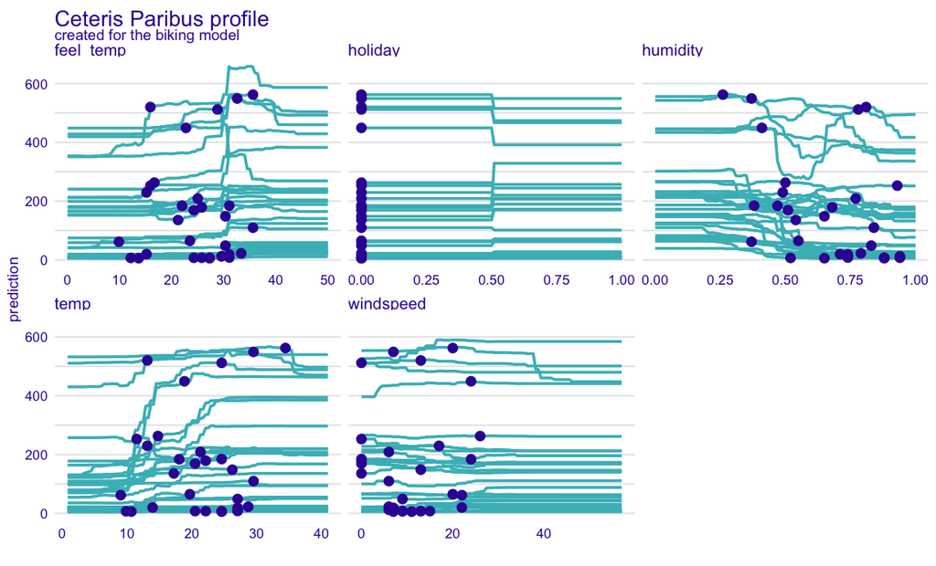

## Global explanations PDP

**Definition [Partial dependence plots (PDP)]**

The PDP plot for feature $k$ is defined as
$$\xi_k(x_k) = \mathbb E_X [\hat m_n(x_k,X_{-k})].$$
Its empirical version is given as
$$\hat \xi_k(x_k)= \frac 1 n \sum_{i=1}^n \eta_i(x_k) = \frac 1 n \sum_{i=1}^n \hat m_n(x_k, X_{i,-k}).$$
More generally, the PDP plot for a set of features $S\subseteq I_p$ is defined as
$$\xi_S(x_S) = \mathbb E_X [\hat m_n(x_S,X_{-S})] = \int \hat{m}(x_S, x_{-S})p_{X_{-S}}(x_{-S}).$$

The empirically version is given as
$$\hat{\xi}_S(x_S) = \frac{1}{n}\sum_{i=1}^n \hat{m}(x_S, X_{i,-S}).$$

## Global explanations PDP

- PDP after fitting Biking data with `ranger`.

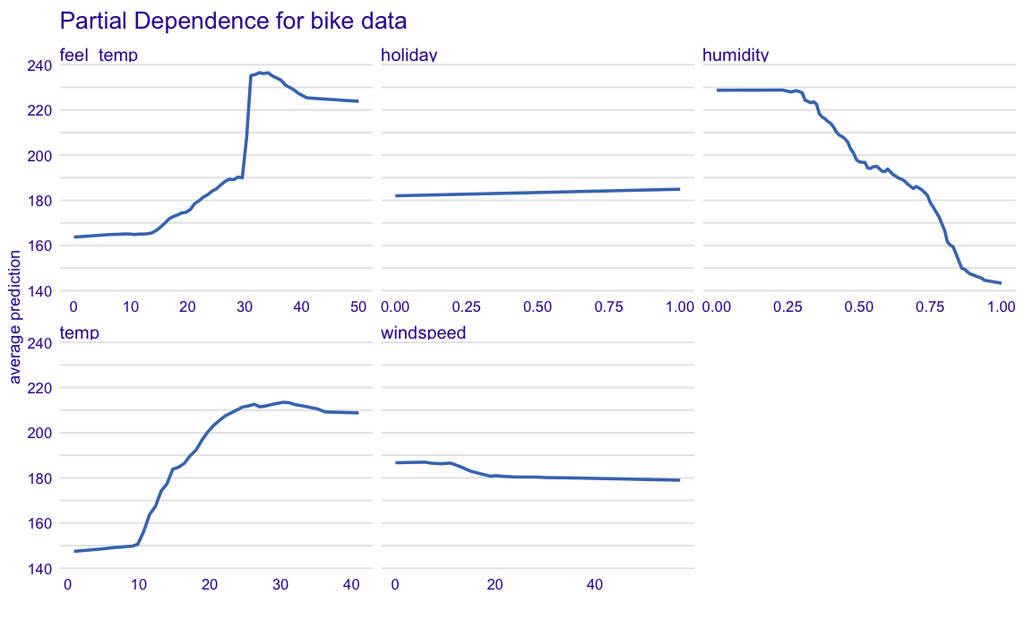

The Extrapolation Issue

## The Extrapolation Issue

- Assume that $p=2$ and that $X_1$ and $X_2$ are highly correlated:
  $$X_1= U+ N(0, 0.05^2), \quad X_2= U+ N(0, 0.05^2), \quad U=\textit{Unif}[0,1].$$
- A simulated scatterplot from 100 observation is shown below
  - The empirical partial dependence plot and the empirical value function of interventional SHAP for $X_1$ at $x_1 = 0.3$ is calculated by taking a simple average of predictions on the blue dots

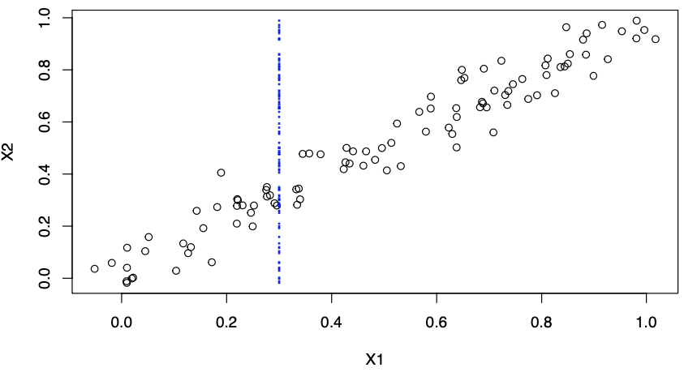

## The Extrapolation Issue

- The problem: The integral in the definition of $v_x(S)=\xi_S(x_S)$ runs over the support of $p_{X_{-S}}$.
- One solution: Modify the definition and let the bounds of the integral depend on the support of $X$, $\mathcal X\subseteq \mathbb R^p$:
  $$\tilde \xi_S(x_S) = \frac{ \int_{x_{-S}: (x_S,x_{-S})\in \mathcal X} \hat{m}_n(x_S, x_{-S})p_{X_{-S}}(x_{-S}) \mathrm dx_{-S}}{\int_{x_{-S}: (x_S,x_{-S})\in \mathcal X} p_{X_{-S}}(x_{-S}) \mathrm dx_{-S} }.$$
- This solution does not seem to be very popular yet in applications and one would need to develop an empirical version of $\tilde \xi_S(x_S)$ that is stable and can be calculated fast. One such proposal can be found in Taufiq, Blöbaum, and Minorics (2023) .

## References

Taufiq, Muhammad Faaiz, Patrick Blöbaum, and Lenon Minorics. 2023. “Manifold Restricted Interventional Shapley Values.” In *International Conference on Artificial Intelligence and Statistics*, 5079–5106. PMLR.